# Predicting NBA Players Performance

Before fitting a regression model to predict certain features, I want to see which features are correlated with each other. I don’t want to train a model on features that have no correlation with the predictor. To see how features are related, I created a heat map.

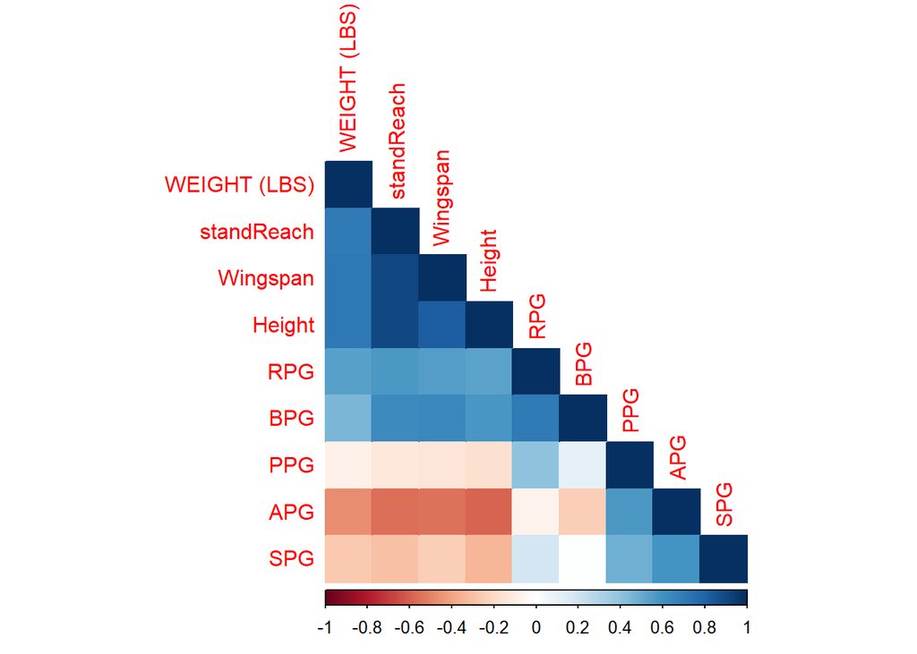

```r
# Corrplot
library(corrplot)
cors <- cor(FinalTable1[, c("WEIGHT (LBS)","standReach", "Wingspan", "Height", "RPG", "BPG", "PPG","APG","SPG")], use = "pairwise.complete.obs")

corTest <- cor.mtest(FinalTable1[, c("WEIGHT (LBS)","standReach", "Wingspan", "Height", "RPG","BPG","PPG","APG","SPG")])
# 0 means significant
corrplot(cors,method = "color", type = "lower")
```

Figure 6: Correlation matrix

```r
# Fit a regression RPG
RPGRegression <- lm(
  data = FinalTable1,
  formula = RPG ~ Height + Wingspan + standReach + `WEIGHT (LBS)`
)

#BPG
BPGRegression <- lm(
  data = FinalTable1,
  formula = BPG ~ Height + Wingspan + standReach + `WEIGHT (LBS)`
)

# PPG
PPGRegression <- lm(
  data = FinalTable1,
  formula = PPG ~ Height + Wingspan + standReach + `WEIGHT (LBS)`
)

# APG
APGRegression <- lm(
  data = FinalTable1,
  formula = APG ~ Height + Wingspan + standReach + `WEIGHT (LBS)`
)

# SPG
SPGRegression <- lm(
  data = FinalTable1,
  formula = SPG ~ Height + Wingspan + standReach + `WEIGHT (LBS)`
)
```

```r
test <- summary(SPGRegression)$coefficients

testdf <- data.frame(test)
testdf %>%
  kable(
    caption = "Coefficients of Steals Per Game as Predictor",
    booktabs = TRUE,
    align = c("l"),
    digits = 4
  ) %>%
  kableExtra::kable_styling(
    bootstrap_options = c("striped", "condensed"),
    font_size = 16
  )
```

Coefficients of Steals Per Game as Predictor

|  | Estimate | Std..Error | t.value | Pr…t.. |
| --- | --- | --- | --- | --- |
| (Intercept) | 3.0750 | 0.4304 | 7.1451 | 0.0000 |
| Height | -0.0349 | 0.0116 | -2.9987 | 0.0029 |
| Wingspan | 0.0124 | 0.0093 | 1.3405 | 0.1808 |
| standReach | -0.0035 | 0.0099 | -0.3590 | 0.7198 |
| `WEIGHT (LBS)` | -0.0014 | 0.0010 | -1.4069 | 0.1602 |

```r
test2 <- summary(APGRegression)$coefficients

testdf2 <- data.frame(test2)
testdf2 %>%
  kable(
    caption = "Coefficients of Assists Per Game as Predictor",
    booktabs = TRUE,
    align = c("l"),
    digits = 4
  ) %>%
  kableExtra::kable_styling(
    bootstrap_options = c("striped", "condensed"),
    font_size = 16
  )
```

Coefficients of Assists Per Game as Predictor

|  | Estimate | Std..Error | t.value | Pr…t.. |
| --- | --- | --- | --- | --- |
| (Intercept) | 20.2624 | 1.5134 | 13.3885 | 0.0000 |
| Height | -0.1637 | 0.0409 | -4.0015 | 0.0001 |
| Wingspan | -0.0554 | 0.0326 | -1.6999 | 0.0899 |
| standReach | 0.0012 | 0.0347 | 0.0353 | 0.9719 |
| `WEIGHT (LBS)` | -0.0054 | 0.0034 | -1.5969 | 0.1110 |

```r
test3 <- summary(PPGRegression)$coefficients

testdf3 <- data.frame(test3)
testdf3 %>%
  kable(
    caption = "Coefficients of Points Per Game as Predictor",
    booktabs = TRUE,
    align = c("l"),
    digits = 4
  ) %>%
  kableExtra::kable_styling(
    bootstrap_options = c("striped", "condensed"),
    font_size = 16
  )
```

Coefficients of Points Per Game as Predictor

|  | Estimate | Std..Error | t.value | Pr…t.. |
| --- | --- | --- | --- | --- |
| (Intercept) | 28.5082 | 5.1164 | 5.5719 | 0.0000 |
| Height | -0.3708 | 0.1383 | -2.6818 | 0.0076 |
| Wingspan | -0.1315 | 0.1101 | -1.1949 | 0.2328 |
| standReach | 0.1651 | 0.1174 | 1.4067 | 0.1603 |
| `WEIGHT (LBS)` | 0.0151 | 0.0114 | 1.3216 | 0.1870 |

```r
test4 <- summary(BPGRegression)$coefficients

testdf4 <- data.frame(test4)
testdf4 %>%
  kable(
    caption = "Coefficients of Blocks Per Game as Predictor",
    booktabs = TRUE,
    align = c("l"),
    digits = 4
  ) %>%
  kableExtra::kable_styling(
    bootstrap_options = c("striped", "condensed"),
    font_size = 16
  )
```

Coefficients of Blocks Per Game as Predictor

|  | Estimate | Std..Error | t.value | Pr…t.. |
| --- | --- | --- | --- | --- |
| (Intercept) | -6.2806 | 0.4626 | -13.5782 | 0.0000 |
| Height | 0.0097 | 0.0125 | 0.7761 | 0.4381 |
| Wingspan | 0.0423 | 0.0100 | 4.2464 | 0.0000 |
| standReach | 0.0268 | 0.0106 | 2.5256 | 0.0119 |
| `WEIGHT (LBS)` | -0.0014 | 0.0010 | -1.3237 | 0.1863 |

```r
test5 <- summary(RPGRegression)$coefficients

testdf5 <- data.frame(test5)
testdf5 %>%
  kable(
    caption = "Coefficients of Rebounds Per Game as Predictor",
    booktabs = TRUE,
    align = c("l"),
    digits = 4
  ) %>%
  kableExtra::kable_styling(
    bootstrap_options = c("striped", "condensed"),
    font_size = 16
  )
```

Coefficients of Rebounds Per Game as Predictor

|  | Estimate | Std..Error | t.value | Pr…t.. |
| --- | --- | --- | --- | --- |
| (Intercept) | -17.2271 | 2.1282 | -8.0947 | 0.0000 |
| Height | -0.0124 | 0.0575 | -0.2151 | 0.8298 |
| Wingspan | 0.0467 | 0.0458 | 1.0196 | 0.3085 |
| standReach | 0.1322 | 0.0488 | 2.7079 | 0.0070 |
| `WEIGHT (LBS)` | 0.0210 | 0.0048 | 4.4146 | 0.0000 |

From the regression summary, we can see how some physical features are related with in game performance.

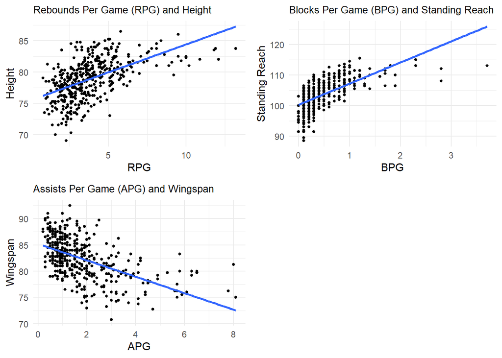

```r
#all visuals are given based on strongest p-value and correlation
# rpg v height
RPG <- ggplot(FinalTable1) +
  aes(x = RPG, y = Height) +
  geom_point(shape = "circle", size = 1) +
  geom_smooth(method = "lm", span = 1L, se = F) +
  labs(title = "Rebounds Per Game (RPG) and Height") +
  theme_minimal() +
   theme(
    plot.title = element_text(size = 10L)
   )

#bpg vs standing reach
BPG <- ggplot(FinalTable1) +
  aes(x = BPG, y = standReach) +
  geom_point(shape = "circle", size = 1) +
  geom_smooth(method = "lm", span = 1L, se = F) +
  labs(
    y = "Standing Reach",
    title = "Blocks Per Game (BPG) and Standing Reach"
  ) +
  theme_minimal() +
   theme(
    plot.title = element_text(size = 10L)
   )

#none for ppg as correlation is weak

# apg and wingspan
APG <- ggplot(FinalTable1) +
  aes(x = APG, y = Wingspan) +
  geom_point(shape = "circle", size = 1) +
  geom_smooth(method = "lm",span = 1L, se = F) +
  labs(title = "Assists Per Game (APG) and Wingspan") +
  theme_minimal() +
   theme(
    plot.title = element_text(size = 10L)
   )

#none for spg as correlation is weak

#join three together
ggarrange(RPG, BPG, APG) + rremove("x.text")
```

Figure 7: Physical Attributes Effects on Performance Metrics

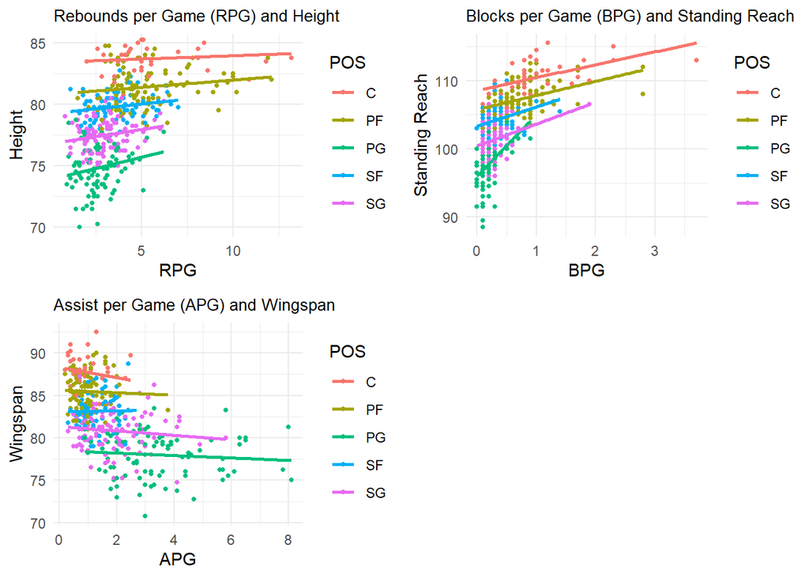

```r
#make same tables, but show with respect to position
RPGPos <- FinalTable1 %>%
  subset(POS == "PG" | POS == "SG" | POS == "SF" | POS == "PF" | POS == "C") %>%
  ggplot() +
  aes(x = RPG, y = Height, colour = POS) +
  geom_point(shape = "circle", size = 1) +
  geom_smooth(method = "lm",span = 0.75, se = F) +
  scale_color_hue(direction = 1) +
  coord_cartesian(ylim = c(70, 85)) +
  labs(title = "Rebounds per Game (RPG) and Height") +
  theme_minimal() +
  theme(
    plot.title = element_text(size = 10L)
  )


#bpg vs standing reach
BPGPos <- FinalTable1 %>%
  subset(POS == "PG" | POS == "SG" | POS == "SF" | POS == "PF" | POS == "C") %>%
  ggplot() +
  aes(x = BPG, y = standReach, colour = POS) +
  geom_point(shape = "circle", size = 1) +
  geom_smooth(method = "lm",span = 0.75, se = F) +
  scale_color_hue(direction = 1) +
  labs(
    y = "Standing Reach",
    title = "Blocks per Game (BPG) and Standing Reach"
  ) +
  theme_minimal() +
  theme(
    plot.title = element_text(size = 10L)
  )


#none for ppg as correlation is weak

# apg and wingspan
APGPos <- FinalTable1 %>%
  subset(POS == "PG" | POS == "SG" | POS == "SF" | POS == "PF" | POS == "C") %>%
  ggplot() +
  aes(x = APG, y = Wingspan, colour = POS) +
  geom_point(shape = "circle", size = 1) +
  geom_smooth(method = "lm",span = .75, se = F) +
  scale_color_hue(direction = 1) +
  labs(title = "Assist per Game (APG) and Wingspan") +
  theme_minimal() +
  theme(
    plot.title = element_text(size = 10L)
  )


ggarrange(RPGPos, BPGPos, APGPos) + rremove("x.text")
```

Figure 8: Physical Attributes Effects on Performance Metrics by Position

These visualizations contain the same data as the prior group of visualizations, but now, a players position is used as a filter. This allows us to see the importance of features depending on a players position. For example, in Rebounds per Game and Height, for the point guard (PG) position, the taller the player, the more rebounds they get. The relationship is apparent and can be seen by the increasing green line. Looking at the Blocks per Game and Standing Reach visualization, it can be seen that standing reach matters more for point guards than any other position. Lastly, in the Assist per Game and Wingspan visualization, a greater wingspan is most detrimental to centers in the amount of assists they get.

```r
#Renaming badly named columns to better names
FinalTable1 <- rename(FinalTable1, HandWidth = `HAND WIDTH (inches)`)
FinalTable1 <- rename(FinalTable1, HandLength = `HAND LENGTH (inches)`)
FinalTable1 <- rename(FinalTable1, Weight = `WEIGHT (LBS)`)
```

```r
#Creating new dataframe with only needed variables
modelDF <- FinalTable1 %>%
  select(-c(`BODY FAT %`,  Player, `#`, FGA, FGM, `FG%`, `3PM`, `3PA`, `3P%`, FTM, FTA, OREB, DREB, EFF, TEAM, `FT%`, MIN, POS))
```

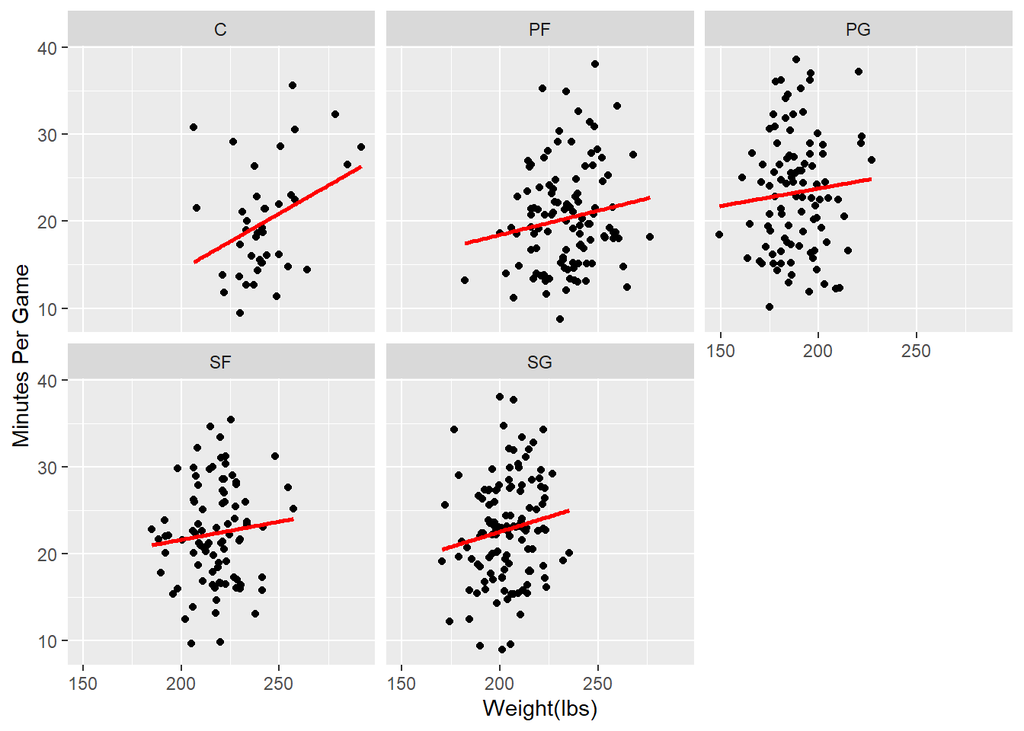

```r
FinalTable1 %>%
  subset(POS == "PG" | POS == "SG" | POS == "SF" | POS == "PF" | POS == "C") %>%
ggplot() +
  aes(x = Weight, y = MIN) +
  geom_point(shape = "circle") +
  geom_smooth(method = "lm", se = F, color = "red") +
  facet_wrap(vars(POS), drop = T) +
  labs(x = "Weight(lbs)",
       y = "Minutes Per Game")
```

Figure 9: Weight Vs Minutes Per Game by Position

I was expecting the heavier players to play less. I came to this assumption because the heavier you are, usually the less stamina you have combined with a higher chance for injury. But as you can see, that assumption was the opposite. Heavier players average more minutes across all positions.

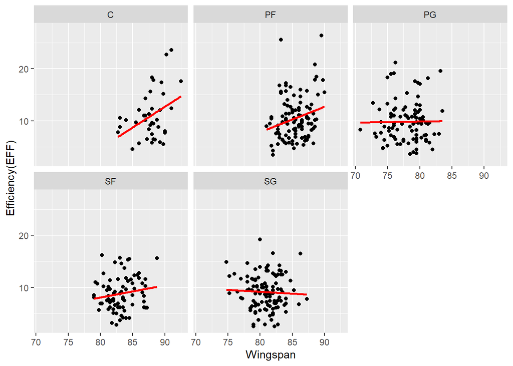

```r
FinalTable1 %>%
  subset(POS == "PG" | POS == "SG" | POS == "SF" | POS == "PF" | POS == "C") %>%
ggplot() +
  aes(x = Wingspan, y = EFF) +
  geom_point(shape = "circle") +
  geom_smooth(method = "lm", se = F, color = "red") +
  facet_wrap(vars(POS), drop = T) +
  labs(y = "Efficiency(EFF)")
```

Figure 10: Wingspan Vs Efficiency by Position

Efficiency(EFF) is a common metric to rank players, it can be calculated by the equation EFF = PTS + STL + REB + AST + STL + BLK - Missed FG + Missed FT - TO / GP

This visualization was one of the most interesting to me. This is because I always thought a greater wingspan was a huge advantage in any position. But it can be seen that wingspan, for the small positions, doesn’t really matter. It is still important for the larger positions.

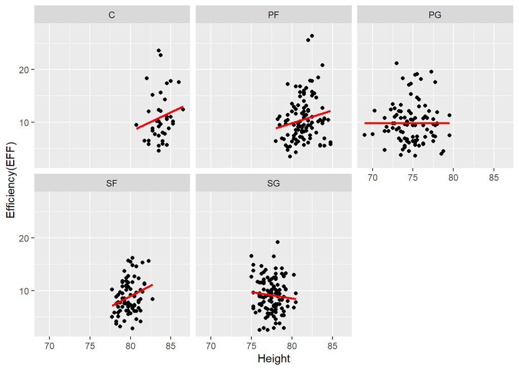

```r
FinalTable1 %>%
  subset(POS == "PG" | POS == "SG" | POS == "SF" | POS == "PF" | POS == "C") %>%
ggplot() +
  aes(x = Height, y = EFF) +
  geom_point(shape = "circle") +
  geom_smooth(method = "lm", se = F, color = "red") +
  facet_wrap(vars(POS), drop = T) +
  labs(y = "Efficiency(EFF)")
```

Figure 11: Height Vs Efficiency by Position

For the smaller positions (PG/SG) there is no correlation between height and efficiency.

## LASSO

```r
modelDF <- modelDF %>%
  na.omit()
```

```r
modelDFCopy <- modelDF
```

```r
Xmat <- model.matrix(PPG ~. -PPG, data=modelDF)[ ,-1]
y <- modelDF$PPG
```

```r
set.seed(123)
train_ind <- sample(1:nrow(Xmat), floor(0.80*nrow(Xmat)))
set.seed(NULL)

X_mat_train <- Xmat[train_ind,]
X_mat_test <- Xmat[-train_ind,]
y_train <- y[train_ind]
y_test <- y[-train_ind]
```

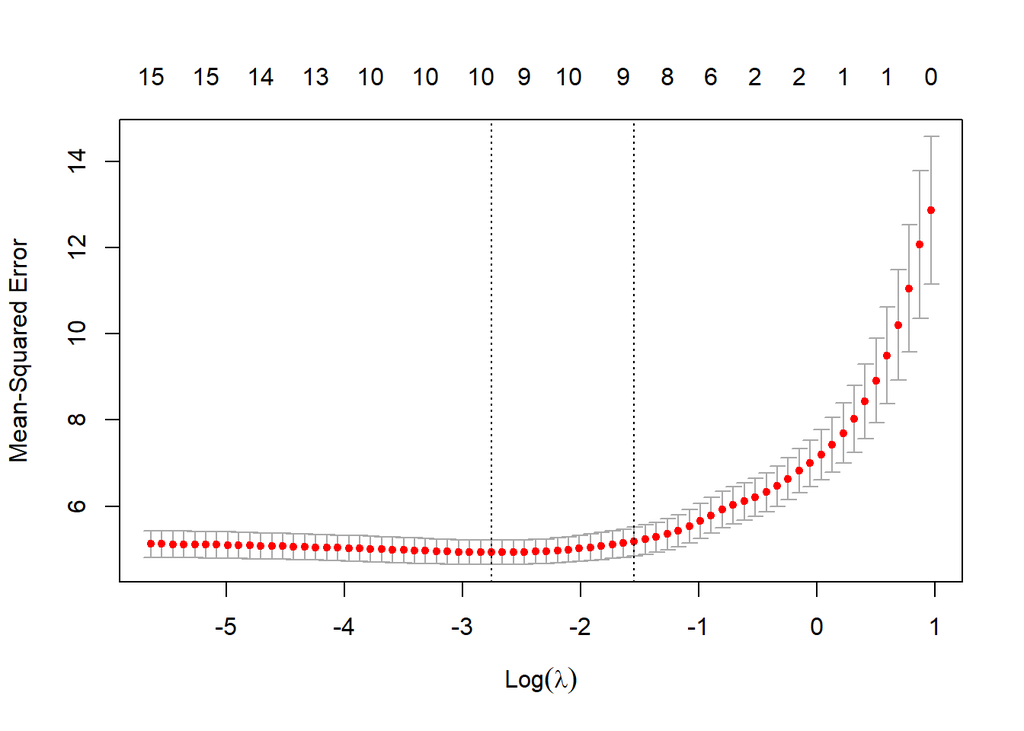

```r
#lasso regression with 10 fold CV
set.seed (123)
cv.out <- cv.glmnet(x= Xmat, y = y,
                    alpha = 1, stanardize = TRUE,
                    nfolds=10)
plot(cv.out)
```

Figure 12: MSE vs log(Lambda)

```r
bestlam1 <- cv.out$lambda.min
lasso.pred1 <- predict(cv.out , s = bestlam1,
                      newx = Xmat)
MSE_lassoMin <- mean((y - lasso.pred1)^2)
RMSE_lassoMin <- sqrt(MSE_lassoMin)


rmse1 <- data.frame(RMSE = RMSE_lassoMin)
rmse1 %>%
  kable(
    caption = "RMSE of LASSO with Minimum Lambda",
    booktabs = TRUE,
    align = c("l"),
    digits = 4
  ) %>%
  kableExtra::kable_styling(
    bootstrap_options = c("striped", "condensed"),
    font_size = 16
  )
```

RMSE of LASSO with Minimum Lambda

| RMSE |
| --- |
| 2.1201 |

```r
lasso.coef1 <- predict(cv.out , s = bestlam1,
                      type = "coefficients")
lasso.coef1
```

```
## 18 x 1 sparse Matrix of class "dgCMatrix"
##                        s1
## (Intercept) 13.1574961139
## GP           0.0008289713
## RPG          0.7147605206
## APG          0.2368601933
## SPG          .
## BPG          .
## TO.          3.2032205708
## HandLength  -0.4101511707
## HandWidth   -0.2318790446
## Weight       .
## standReach   .
## Wingspan    -0.0746494279
## Height       .
## PG           .
## SG           1.2906810006
## SF           0.5451105816
## PF           .
## C           -0.8736044630
```

Figure 13: Coefficients of LASSO with Lambda that yields min MSE

The variables that LASSO removed are: SPG, BPG, Weight, standReach, Height, PG, and PF.